# Plot Results

Alex Stern

2022-04-28

# Increasing Allele Frequency for Various Traits

This code builds off of a previous pipeline which takes GWAS data and returns the average increasing allele frequency (with confidence intervals) for various phenotypes. Using these output files, this code creates a bar graph that compares the mean increasing allele frequency for a select few of these traits. A p-value threshold of 1e-5 is used throughout this report to create a cutoff for which SNP’s are considered significant.

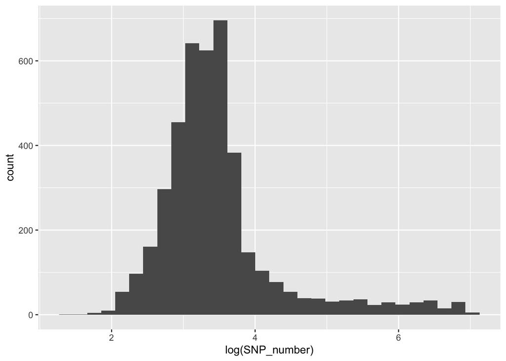

```r
df_all <- fread("output/results/all_1e-5_0.01.txt.gz")
df_all <- drop_na(df_all, SNP_number)
df_all <- distinct(df_all, phenotype_name, .keep_all= TRUE)

ggplot(data = df_all, mapping = aes(x = log(SNP_number))) + geom_histogram()
```

We then filtered out all traits with less than 10 significant SNPs. The SNP numbers were again plotted in a histogram, not on a logarithmic scale this time.

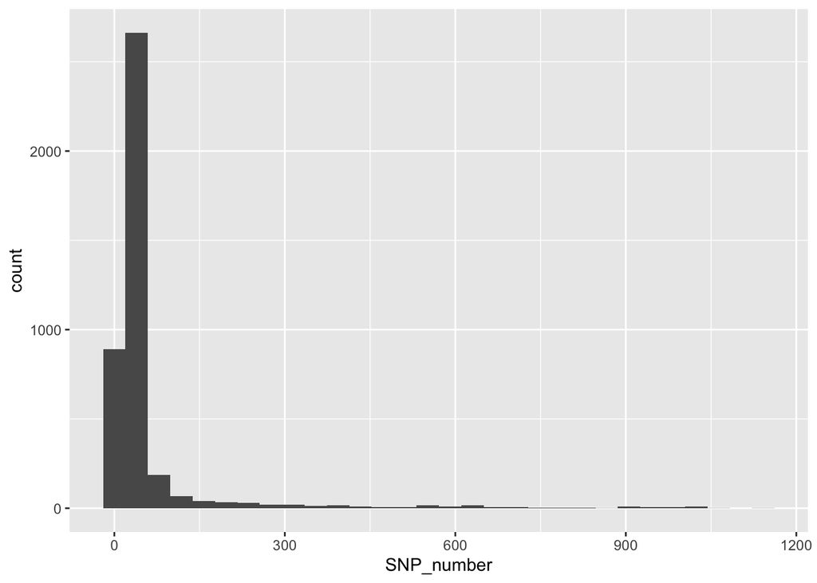

```r
df_10 <- filter(df_all, SNP_number >= 10)
ggplot(data = df_10, mapping = aes(x = SNP_number)) + geom_histogram()
```

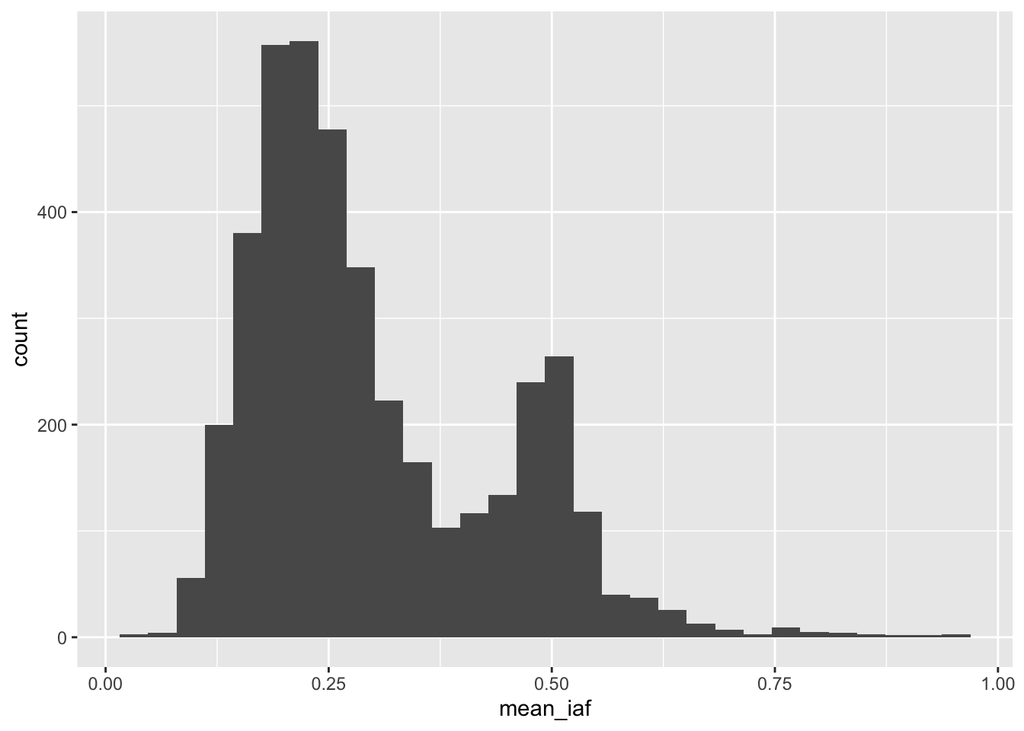

```r
ggplot(data = df_10, mapping = aes(x = mean_iaf)) + geom_histogram()
```

We calculated the average of the mean iaf’s for all of the traits with more than 10 SNP’s.

```r
mean_of_mean_iaf <- mean(df_10[,mean_iaf])
mean_of_mean_iaf
```

```
## [1] 0.3002762
```

The average is below 0.5, suggesting mutational bias towards increasing alleles.

We then filtered our data into two groups. The first group was of traits with a mean increasing allele frequency statistically significantly higher than 0.5. The second was of traits significantly lower than 0.5. Traits whose confidence intervals included 0.5 we removed entirely.

```r
df_sig_dif <- filter(df_10, lower_ci > 0.5 | 0.5 > upper_ci)
df_greater_0.5 <- filter(df_sig_dif, lower_ci > 0.5)
df_less_0.5 <- filter(df_sig_dif, 0.5 > upper_ci)
```

```r
num_traits <- nrow(df_10)
traits_greater <- nrow(df_greater_0.5)
percent_greater <- traits_greater/num_traits
traits_less <- nrow(df_less_0.5)
percent_less <- traits_less/num_traits
```

```r
cat("There were ", traits_greater, " traits with mean iaf significantly higher than 0.5.
This is ", 100*round(percent_greater, 4), "% of traits with 10 or more significant SNPs.")
```

```
## There were  94  traits with mean iaf significantly higher than 0.5.
## This is  2.29 % of traits with 10 or more significant SNPs.
```

```r
cat("There were ", traits_less, " traits with mean iaf significantly lower than 0.5.
This is ", 100*round(percent_less, 4), "% of traits with 10 or more significant SNPs.")
```

```
## There were  3094  traits with mean iaf significantly lower than 0.5.
## This is  75.37 % of traits with 10 or more significant SNPs.
```

```r
plot_data <- function(dat, title) {
  pl <- ggplot(data = dat, mapping = aes(x = reorder(phenotype_name, -mean_iaf), y = mean_iaf)) + geom_col(fill = "lightblue1") + theme(axis.text.x = element_text(angle = 45, hjust = 1, size = 3)) + geom_errorbar(aes(y = mean_iaf, ymax = upper_ci, ymin = lower_ci)) + geom_point(aes(y = mean_iaf)) + geom_hline(yintercept = 0.5, alpha = 0.5, linetype = "dashed", color = "red") + ggtitle(title) + xlab("Phenotype") + ylab("Mean Increasing Allele Frequency") + theme(plot.title    = element_text(family = "mono", size = 10),
        axis.title.x  = element_text(family = "mono"),
        axis.title.y  = element_text(family = "mono"),
        axis.text.x   = element_blank(),
        axis.ticks.x = element_blank(),
        axis.text.y   = element_text(family = "mono"),
  panel.background = element_rect(fill = "white",
                                colour = "white",
                                size = 0.5, linetype = "solid"),
  panel.grid.major = element_line(size = 0.25, linetype = 'solid',
                                colour = "grey"),
  panel.grid.minor = element_line(size = 0.25, linetype = 'solid',
                                colour = "grey"))
  return(pl)
}
```

We then plotted the mean increasing allele frequency with error for all of the traits with mean iaf significantly greater than 0.5.

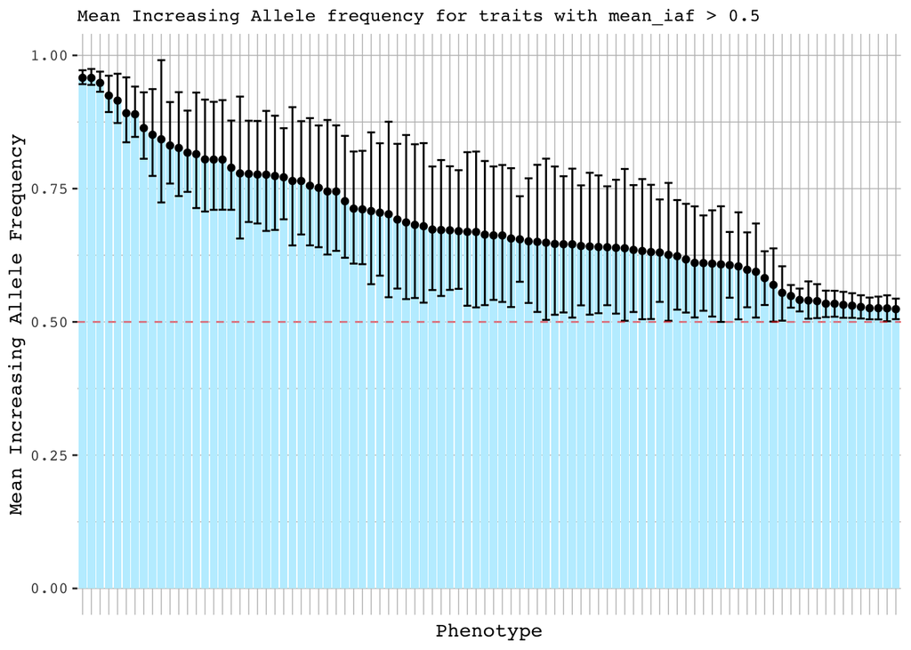

```r
plot_data(df_greater_0.5, "Mean Increasing Allele frequency for traits with mean_iaf > 0.5")
```

The following table contains the phenotype names for all of the traits included in the above graph. They are sorted in the order they appear from left to right.

```r
greater_table <- select(df_greater_0.5, c("mean_iaf", "SNP_number", "phenotype_name")) %>% arrange(desc(mean_iaf))
kable(greater_table)
```

| mean_iaf | SNP_number | phenotype_name |
| --- | --- | --- |
| 0.9579103 | 178 | Both eyes present: Yes |
| 0.9578194 | 99 | Ever had laser treatment for glaucoma or high eye pressure: No |
| 0.9483764 | 124 | Ever had corneal graft surgery: No |
| 0.9245941 | 82 | Surgery/amputation of toe or leg: No |
| 0.9152119 | 57 | Illnesses of adopted siblings: None of the above (group 2) |
| 0.8915831 | 43 | Night shifts worked: This type of shift pattern was not worked during job |
| 0.8895757 | 56 | Worked with pesticides: Rarely/never |
| 0.8636351 | 37 | Number of triplets attempted (left) |
| 0.8511145 | 18 | Recent medication for COPD (Chronic Obstructive Pulmonary Disease) |
| 0.8426164 | 19 | Previously smoked cigarettes on most/all days |
| 0.8309027 | 41 | Breathing problems during period of job: No |
| 0.8263211 | 36 | Worked with materials containing asbestos: Rarely/never |
| 0.8174949 | 43 | General pain for 3+ months |
| 0.8147173 | 28 | Fat removed from meat |
| 0.8048952 | 35 | Age cataract diagnosed |
| 0.8045774 | 24 | Which eye(s) affected by myopia (short sight): Both eyes |
| 0.8045394 | 33 | Age stroke diagnosed |
| 0.7892228 | 34 | Number of triplets attempted (right) |
| 0.7786546 | 23 | Illnesses of adopted father: None of the above (group 2) |
| 0.7777325 | 33 | FI2 : identify largest number |
| 0.7765122 | 27 | Likelihood of resuming smoking |
| 0.7761910 | 25 | Job involved shift work: No |
| 0.7736931 | 28 | Completion status of test: Fully completed |
| 0.7713125 | 35 | Which eye(s) affected by hypermetropia (long sight): Both eyes |
| 0.7644399 | 21 | Which eye(s) affected by astigmatism: Both eyes |
| 0.7643738 | 36 | Final attempt correct: yes |
| 0.7554557 | 24 | Hearing test done: Yes |
| 0.7515264 | 27 | Difficulty stopping worrying during worst period of anxiety |
| 0.7446948 | 24 | Illnesses of adopted siblings: None of the above (group 1) |
| 0.7446802 | 33 | Ever been injured or injured someone else through drinking alcohol: No |

[output cut: 64 more lines]

Finally, we plotted the mean increasing allele frequency for traits with mean iaf significantly less than 0.5.

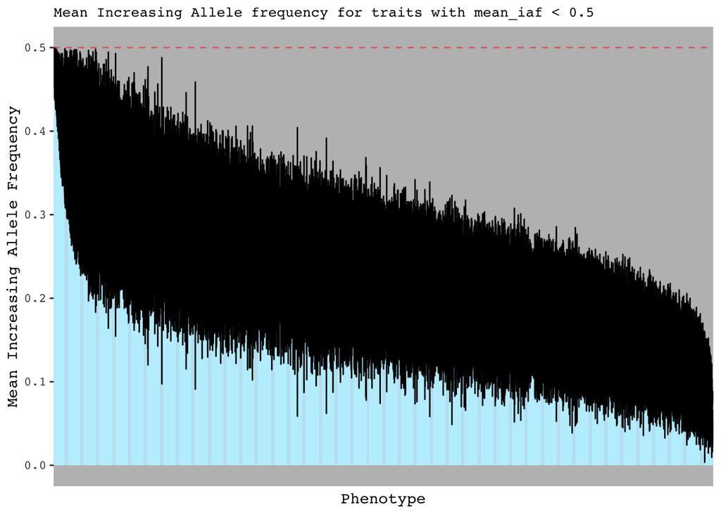

```r
plot_data(df_less_0.5, "Mean Increasing Allele frequency for traits with mean_iaf < 0.5")
```

A table containing the data represented in the bar graph is included below. Due the large number of traits with significant SNP’s, only the 200 traits with the highest and lowest mean iaf values are displayed.

```r
less_table <- select(df_less_0.5, c("mean_iaf", "SNP_number", "phenotype_name")) %>% arrange(desc(mean_iaf))
kable(head(less_table, 100))
```

| mean_iaf | SNP_number | phenotype_name |
| --- | --- | --- |
| 0.4792598 | 641 | Haematocrit percentage |
| 0.4787391 | 692 | High light scatter reticulocyte count |
| 0.4735191 | 654 | Reticulocyte count |
| 0.4731082 | 665 | High light scatter reticulocyte percentage |
| 0.4691816 | 349 | Alanine aminotransferase (U/L) |
| 0.4682042 | 262 | Plays computer games |
| 0.4675897 | 449 | Qualifications: None of the above |
| 0.4669448 | 628 | Reticulocyte percentage |
| 0.4643177 | 235 | Nervous feelings |
| 0.4633277 | 222 | Intra-ocular pressure, Goldmann-correlated (right) |
| 0.4627744 | 261 | Relative age of first facial hair |
| 0.4599568 | 357 | Alcohol intake frequency. |
| 0.4590060 | 557 | Cystatin C (mg/L) |
| 0.4579955 | 188 | C-reactive protein (mg/L) |
| 0.4553221 | 265 | Aspartate aminotransferase (U/L) |
| 0.4551206 | 163 | Current tobacco smoking |
| 0.4513512 | 166 | Glucose (mmol/L) |
| 0.4509290 | 168 | Smoking status: Current |
| 0.4484510 | 487 | Creatinine (umol/L) |
| 0.4447419 | 182 | Non-cancer illness code, self-reported: high cholesterol |
| 0.4438421 | 227 | Mean corpuscular haemoglobin concentration |
| 0.4433855 | 206 | Frequency of tiredness / lethargy in last 2 weeks |
| 0.4430719 | 123 | Pain type(s) experienced in last month: Back pain |
| 0.4397910 | 168 | Tea intake |
| 0.4369906 | 327 | Hair colour (natural, before greying): Blonde |
| 0.4368547 | 157 | Medication for cholesterol, blood pressure or diabetes: Cholesterol lowering medication |
| 0.4350941 | 103 | Own or rent accommodation lived in: Rent - from local authority, local council, housing association |
| 0.4342840 | 139 | Frequency of depressed mood in last 2 weeks |
| 0.4262799 | 185 | Treatment/medication code: levothyroxine sodium |
| 0.4259945 | 90 | Exposure to tobacco smoke outside home |

[output cut: 70 more lines]

```r
kable(tail(less_table, 100))
```

| mean_iaf | SNP_number | phenotype_name |
| --- | --- | --- |
| 0.1214711 | 43 | Treatment/medication code: adalat 5mg capsule |
| 0.1214171 | 22 | Job SOC coding: Electrical/electronics engineers n.e.c. |
| 0.1214114 | 31 | Diagnoses - main ICD10: N60 Benign mammary dysplasia |
| 0.1212171 | 27 | Blepharochalasis |
| 0.1206562 | 19 | Diagnoses - main ICD10: K05 Gingivitis and periodontal diseases |
| 0.1205520 | 39 | Non-cancer illness code, self-reported: transient ischaemic attack (tia) |
| 0.1204620 | 47 | Job SOC coding: Youth and community workers |
| 0.1203553 | 18 | Illnesses of adopted father: Lung cancer |
| 0.1203137 | 39 | Job coding: civil service senior manager outside the senior civil service (former grades 6 and 7) |
| 0.1201319 | 27 | Treatment/medication code: nifedipine |
| 0.1196288 | 40 | Mood [affective] disorders |
| 0.1196288 | 40 | Mood disorders |
| 0.1196183 | 16 | Job coding: housekeeper, butler, valet, cook-housekeeper, companion-housekeeper |
| 0.1192626 | 30 | Diagnoses - main ICD10: I65 Occlusion and stenosis of precerebral arteries, not resulting in cerebral infarction |
| 0.1187097 | 34 | Type of fat/oil used in cooking: Low fat olive spread for |
| 0.1186148 | 34 | Diagnoses - main ICD10: T85 Complications of other internal prosthetic devices, implants and grafts |
| 0.1183243 | 39 | Non-rheumatic valve diseases |
| 0.1183048 | 38 | Diagnoses - main ICD10: J32 Chronic sinusitis |
| 0.1182033 | 18 | Job SOC coding: Quality assurance technicians |
| 0.1181850 | 37 | Chest pain felt outside physical activity |
| 0.1178114 | 33 | Diagnoses - main ICD10: R32 Unspecified urinary incontinence |
| 0.1176262 | 28 | Treatment/medication code: domperidone |
| 0.1168998 | 24 | Diagnoses - main ICD10: N45 Orchitis and epididymitis |
| 0.1165952 | 41 | Diagnoses - main ICD10: I44 Atrioventricular and left bundle-branch block |
| 0.1160010 | 37 | Diagnoses - main ICD10: N97 Female infertility |
| 0.1154488 | 25 | Diagnoses - main ICD10: Z41 Procedures for purposes other than remedying health state |
| 0.1153955 | 34 | Diagnoses - main ICD10: O63 Long labour |
| 0.1134114 | 27 | Malignant neoplasm of lip, oral cavity and pharynx |
| 0.1133673 | 34 | Job coding: nursing auxiliary or assistant, steriliser of medical equipment, occupational therapy assistant, phlebotomist, physiotherapy assistant, ward orderly, ward assistant |
| 0.1125184 | 43 | Rose wine intake |

[output cut: 70 more lines]

Use of the p-value of 1e-5 to filter out significant SNPs vastly alters the results from the 5e-8 analysis. The average mean_iaf is significantly less than 0.5 compared to the previous data. Further investigation is needed to determine why this occurs.